# Predicting Property Value

# Importing Dataset

```r
df <- read.csv("melbourne_housing.csv")
head(df, 10)
```

```
##        Suburb            Address Rooms Type   Price Method SellerG      Date
## 1  Abbotsford       85 Turner St     2    h 1480000      S  Biggin 3/12/2016
## 2  Abbotsford    25 Bloomburg St     2    h 1035000      S  Biggin  4/2/2016
## 3  Abbotsford       5 Charles St     3    h 1465000     SP  Biggin  4/3/2017
## 4  Abbotsford   40 Federation La     3    h  850000     PI  Biggin  4/3/2017
## 5  Abbotsford        55a Park St     4    h 1600000     VB  Nelson  4/6/2016
## 6  Abbotsford     129 Charles St     2    h  941000      S  Jellis  7/5/2016
## 7  Abbotsford       124 Yarra St     3    h 1876000      S  Nelson  7/5/2016
## 8  Abbotsford      98 Charles St     2    h 1636000      S  Nelson 8/10/2016
## 9  Abbotsford 6/241 Nicholson St     1    u  300000      S  Biggin 8/10/2016
## 10 Abbotsford      10 Valiant St     2    h 1097000      S  Biggin 8/10/2016
##    Distance Postcode Bedroom2 Bathroom Car Landsize BuildingArea YearBuilt
## 1       2.5     3067        2        1   1      202           NA        NA
## 2       2.5     3067        2        1   0      156           79      1900
## 3       2.5     3067        3        2   0      134          150      1900
```

[output cut: 18 more lines]

# Data Cleaning

```r
# Checking variables and their types
glimpse(df)
```

```
## Rows: 13,580
## Columns: 21
## $ Suburb        <chr> "Abbotsford", "Abbotsford", "Abbotsford", "Abbotsford", …
## $ Address       <chr> "85 Turner St", "25 Bloomburg St", "5 Charles St", "40 F…
## $ Rooms         <int> 2, 2, 3, 3, 4, 2, 3, 2, 1, 2, 2, 3, 2, 2, 1, 2, 3, 3, 3,…
## $ Type          <chr> "h", "h", "h", "h", "h", "h", "h", "h", "u", "h", "u", "…
## $ Price         <int> 1480000, 1035000, 1465000, 850000, 1600000, 941000, 1876…
## $ Method        <chr> "S", "S", "SP", "PI", "VB", "S", "S", "S", "S", "S", "VB…
## $ SellerG       <chr> "Biggin", "Biggin", "Biggin", "Biggin", "Nelson", "Jelli…
## $ Date          <chr> "3/12/2016", "4/2/2016", "4/3/2017", "4/3/2017", "4/6/20…
## $ Distance      <dbl> 2.5, 2.5, 2.5, 2.5, 2.5, 2.5, 2.5, 2.5, 2.5, 2.5, 2.5, 2…
## $ Postcode      <int> 3067, 3067, 3067, 3067, 3067, 3067, 3067, 3067, 3067, 30…
## $ Bedroom2      <int> 2, 2, 3, 3, 3, 2, 4, 2, 1, 3, 2, 3, 2, 2, 1, 2, 3, 2, 3,…
## $ Bathroom      <int> 1, 1, 2, 2, 1, 1, 2, 1, 1, 1, 2, 2, 2, 1, 1, 1, 2, 1, 1,…
## $ Car           <int> 1, 0, 0, 1, 2, 0, 0, 2, 1, 2, 1, 2, 1, 1, 1, 2, 1, 1, 0,…
## $ Landsize      <int> 202, 156, 134, 94, 120, 181, 245, 256, 0, 220, 0, 214, 0…
## $ BuildingArea  <dbl> NA, 79, 150, NA, 142, NA, 210, 107, NA, 75, NA, 190, 94,…
## $ YearBuilt     <int> NA, 1900, 1900, NA, 2014, NA, 1910, 1890, NA, 1900, NA, …
## $ CouncilArea   <chr> "Yarra", "Yarra", "Yarra", "Yarra", "Yarra", "Yarra", "Y…
## $ Lattitude     <dbl> -37.7996, -37.8079, -37.8093, -37.7969, -37.8072, -37.80…
## $ Longtitude    <dbl> 144.9984, 144.9934, 144.9944, 144.9969, 144.9941, 144.99…
## $ Regionname    <chr> "Northern Metropolitan", "Northern Metropolitan", "North…
## $ Propertycount <int> 4019, 4019, 4019, 4019, 4019, 4019, 4019, 4019, 4019, 40…
```

```r
# Checking number of distinct values of each variable
df %>% summarize_all(n_distinct)
```

```
##   Suburb Address Rooms Type Price Method SellerG Date Distance Postcode
## 1    314   13378     9    3  2204      5     268   58      202      198
##   Bedroom2 Bathroom Car Landsize BuildingArea YearBuilt CouncilArea Lattitude
## 1       12        9  12     1448          603       145          34      6503
##   Longtitude Regionname Propertycount
## 1       7063          8           311
```

```r
# Checking NAs
df %>% summarize_all(funs(sum(is.na(.))))
```

```
##   Suburb Address Rooms Type Price Method SellerG Date Distance Postcode
## 1      0       0     0    0     0      0       0    0        0        0
##   Bedroom2 Bathroom Car Landsize BuildingArea YearBuilt CouncilArea Lattitude
## 1        0        0  62        0         6450      5375           0         0
##   Longtitude Regionname Propertycount
## 1          0          0             0
```

## Dealing with NA’s

We first drop the rows with no Years built and no Building Area as that means there isn’t a building on the property.

```r
df <- df %>% filter(!is.na(YearBuilt) & !is.na(BuildingArea))
head(df, 10)
```

```
##        Suburb             Address Rooms Type   Price Method SellerG       Date
## 1  Abbotsford     25 Bloomburg St     2    h 1035000      S  Biggin   4/2/2016
## 2  Abbotsford        5 Charles St     3    h 1465000     SP  Biggin   4/3/2017
## 3  Abbotsford         55a Park St     4    h 1600000     VB  Nelson   4/6/2016
## 4  Abbotsford        124 Yarra St     3    h 1876000      S  Nelson   7/5/2016
## 5  Abbotsford       98 Charles St     2    h 1636000      S  Nelson  8/10/2016
## 6  Abbotsford       10 Valiant St     2    h 1097000      S  Biggin  8/10/2016
## 7  Abbotsford     40 Nicholson St     3    h 1350000     VB  Nelson 12/11/2016
## 8  Abbotsford 123/56 Nicholson St     2    u  750000      S  Biggin 12/11/2016
## 9  Abbotsford       16 William St     2    h 1310000      S  Jellis 15/10/2016
## 10 Abbotsford         42 Henry St     3    h 1200000      S  Jellis 16/07/2016
##    Distance Postcode Bedroom2 Bathroom Car Landsize BuildingArea YearBuilt
## 1       2.5     3067        2        1   0      156           79      1900
## 2       2.5     3067        3        2   0      134          150      1900
## 3       2.5     3067        3        1   2      120          142      2014
```

[output cut: 18 more lines]

We then change the NA’s in `Car` as it means there is no car slot for the data.

```r
df <- df %>% mutate(Car = ifelse(is.na(Car), 0, Car))
head(df, 10)
```

```
##        Suburb             Address Rooms Type   Price Method SellerG       Date
## 1  Abbotsford     25 Bloomburg St     2    h 1035000      S  Biggin   4/2/2016
## 2  Abbotsford        5 Charles St     3    h 1465000     SP  Biggin   4/3/2017
## 3  Abbotsford         55a Park St     4    h 1600000     VB  Nelson   4/6/2016
## 4  Abbotsford        124 Yarra St     3    h 1876000      S  Nelson   7/5/2016
## 5  Abbotsford       98 Charles St     2    h 1636000      S  Nelson  8/10/2016
## 6  Abbotsford       10 Valiant St     2    h 1097000      S  Biggin  8/10/2016
## 7  Abbotsford     40 Nicholson St     3    h 1350000     VB  Nelson 12/11/2016
## 8  Abbotsford 123/56 Nicholson St     2    u  750000      S  Biggin 12/11/2016
## 9  Abbotsford       16 William St     2    h 1310000      S  Jellis 15/10/2016
## 10 Abbotsford         42 Henry St     3    h 1200000      S  Jellis 16/07/2016
##    Distance Postcode Bedroom2 Bathroom Car Landsize BuildingArea YearBuilt
## 1       2.5     3067        2        1   0      156           79      1900
## 2       2.5     3067        3        2   0      134          150      1900
## 3       2.5     3067        3        1   2      120          142      2014
```

[output cut: 18 more lines]

Now we have a dataset with no NA’s!

## Dropping useless columns 1

```r
df <- df %>% select(-c(Address, Suburb, Method, Postcode, Bedroom2, SellerG, Propertycount))
head(df, 10)
```

```
##    Rooms Type   Price       Date Distance Bathroom Car Landsize BuildingArea
## 1      2    h 1035000   4/2/2016      2.5        1   0      156           79
## 2      3    h 1465000   4/3/2017      2.5        2   0      134          150
## 3      4    h 1600000   4/6/2016      2.5        1   2      120          142
## 4      3    h 1876000   7/5/2016      2.5        2   0      245          210
## 5      2    h 1636000  8/10/2016      2.5        1   2      256          107
## 6      2    h 1097000  8/10/2016      2.5        1   2      220           75
## 7      3    h 1350000 12/11/2016      2.5        2   2      214          190
## 8      2    u  750000 12/11/2016      2.5        2   1        0           94
## 9      2    h 1310000 15/10/2016      2.5        1   2      238           97
## 10     3    h 1200000 16/07/2016      2.5        2   1      113          110
##    YearBuilt CouncilArea Lattitude Longtitude            Regionname
## 1       1900       Yarra  -37.8079   144.9934 Northern Metropolitan
## 2       1900       Yarra  -37.8093   144.9944 Northern Metropolitan
## 3       2014       Yarra  -37.8072   144.9941 Northern Metropolitan
## 4       1910       Yarra  -37.8024   144.9993 Northern Metropolitan
## 5       1890       Yarra  -37.8060   144.9954 Northern Metropolitan
## 6       1900       Yarra  -37.8010   144.9989 Northern Metropolitan
## 7       2005       Yarra  -37.8085   144.9964 Northern Metropolitan
## 8       2009       Yarra  -37.8078   144.9965 Northern Metropolitan
## 9       1890       Yarra  -37.8090   144.9976 Northern Metropolitan
## 10      1880       Yarra  -37.8056   144.9930 Northern Metropolitan
```

## Dropping useless columns 2

```r
df$YearSold <- as.numeric(format(as.Date(df$Date, format="%d/%m/%Y"),"%Y"))
df$MonthSold <- as.numeric(format(as.Date(df$Date, format="%d/%m/%Y"),"%m"))
df$MonthsSince2016 <- (df$YearSold-2016)*12 + df$MonthSold
df <- df %>% mutate(BuildingAge=YearSold-YearBuilt) %>% filter(BuildingAge >= 0)
df <- df %>% select(Price, Regionname, MonthsSince2016, BuildingAge, Landsize, BuildingArea, Lattitude, Longtitude, Type, Rooms, Distance, Bathroom, Car)
head(df, 10)
```

```
##      Price            Regionname MonthsSince2016 BuildingAge Landsize
## 1  1035000 Northern Metropolitan               2         116      156
## 2  1465000 Northern Metropolitan              15         117      134
## 3  1600000 Northern Metropolitan               6           2      120
## 4  1876000 Northern Metropolitan               5         106      245
## 5  1636000 Northern Metropolitan              10         126      256
## 6  1097000 Northern Metropolitan              10         116      220
## 7  1350000 Northern Metropolitan              11          11      214
## 8   750000 Northern Metropolitan              11           7        0
## 9  1310000 Northern Metropolitan              10         126      238
## 10 1200000 Northern Metropolitan               7         136      113
##    BuildingArea Lattitude Longtitude Type Rooms Distance Bathroom Car
## 1            79  -37.8079   144.9934    h     2      2.5        1   0
## 2           150  -37.8093   144.9944    h     3      2.5        2   0
## 3           142  -37.8072   144.9941    h     4      2.5        1   2
## 4           210  -37.8024   144.9993    h     3      2.5        2   0
## 5           107  -37.8060   144.9954    h     2      2.5        1   2
## 6            75  -37.8010   144.9989    h     2      2.5        1   2
## 7           190  -37.8085   144.9964    h     3      2.5        2   2
## 8            94  -37.8078   144.9965    u     2      2.5        2   1
## 9            97  -37.8090   144.9976    h     2      2.5        1   2
## 10          110  -37.8056   144.9930    h     3      2.5        2   1
```

## Refactoring Features

```r
df <- df %>% transform(
  Price=as.double(Price),
  Regionname=as.factor(Regionname),
  MonthsSince2016=as.integer(MonthsSince2016),
  Landsize=as.double(Landsize),
  Type=as.factor(Type),
  Car=as.integer(Car)
)

head(df, 10)
```

```
##      Price            Regionname MonthsSince2016 BuildingAge Landsize
## 1  1035000 Northern Metropolitan               2         116      156
## 2  1465000 Northern Metropolitan              15         117      134
## 3  1600000 Northern Metropolitan               6           2      120
## 4  1876000 Northern Metropolitan               5         106      245
## 5  1636000 Northern Metropolitan              10         126      256
## 6  1097000 Northern Metropolitan              10         116      220
## 7  1350000 Northern Metropolitan              11          11      214
## 8   750000 Northern Metropolitan              11           7        0
## 9  1310000 Northern Metropolitan              10         126      238
## 10 1200000 Northern Metropolitan               7         136      113
##    BuildingArea Lattitude Longtitude Type Rooms Distance Bathroom Car
## 1            79  -37.8079   144.9934    h     2      2.5        1   0
## 2           150  -37.8093   144.9944    h     3      2.5        2   0
## 3           142  -37.8072   144.9941    h     4      2.5        1   2
## 4           210  -37.8024   144.9993    h     3      2.5        2   0
## 5           107  -37.8060   144.9954    h     2      2.5        1   2
## 6            75  -37.8010   144.9989    h     2      2.5        1   2
## 7           190  -37.8085   144.9964    h     3      2.5        2   2
## 8            94  -37.8078   144.9965    u     2      2.5        2   1
## 9            97  -37.8090   144.9976    h     2      2.5        1   2
## 10          110  -37.8056   144.9930    h     3      2.5        2   1
```

## Dropping Unusual Data

```r
df <- df %>% filter(BuildingArea < 1250)
df <- df %>% filter(Price < 5000000)
```

## Exporting Cleaned Dataset

```r
write.csv(df, "cleaned_df.csv", row.names = F)
```

Now we’re done cleaning!

# Exploratory Analysis

## Numerical Variables

### Summary and Scale Normalization

```r
num_df <- df %>% select(where(is.numeric))
summary(num_df)
```

```
##      Price         MonthsSince2016  BuildingAge        Landsize
##  Min.   : 131000   Min.   : 2.00   Min.   :  0.00   Min.   :    0.0
##  1st Qu.: 630000   1st Qu.: 9.00   1st Qu.: 17.00   1st Qu.:  165.0
##  Median : 890000   Median :12.00   Median : 47.00   Median :  401.0
##  Mean   :1067740   Mean   :13.05   Mean   : 52.23   Mean   :  486.7
##  3rd Qu.:1330500   3rd Qu.:18.00   3rd Qu.: 76.00   3rd Qu.:  640.0
##  Max.   :4850000   Max.   :21.00   Max.   :821.00   Max.   :37000.0
##   BuildingArea      Lattitude        Longtitude        Rooms
##  Min.   :   0.0   Min.   :-38.16   Min.   :144.5   Min.   :1.000
##  1st Qu.:  93.0   1st Qu.:-37.86   1st Qu.:144.9   1st Qu.:2.000
##  Median : 125.0   Median :-37.80   Median :145.0   Median :3.000
##  Mean   : 142.2   Mean   :-37.81   Mean   :145.0   Mean   :2.973
##  3rd Qu.: 172.0   3rd Qu.:-37.76   3rd Qu.:145.1   3rd Qu.:4.000
##  Max.   :1041.0   Max.   :-37.41   Max.   :145.5   Max.   :8.000
##     Distance        Bathroom          Car
##  Min.   : 0.00   Min.   :1.000   Min.   : 0.000
##  1st Qu.: 6.10   1st Qu.:1.000   1st Qu.: 1.000
##  Median : 9.20   Median :1.000   Median : 2.000
##  Mean   :10.13   Mean   :1.589   Mean   : 1.598
##  3rd Qu.:13.00   3rd Qu.:2.000   3rd Qu.: 2.000
##  Max.   :47.40   Max.   :8.000   Max.   :10.000
```

### Correlation Matrix

```r
correlationmatrix_df = round(cor(num_df), 2)
correlationmatrix_df
```

```
##                 Price MonthsSince2016 BuildingAge Landsize BuildingArea
## Price            1.00           -0.02        0.31     0.07         0.57
## MonthsSince2016 -0.02            1.00       -0.10     0.10         0.04
## BuildingAge      0.31           -0.10        1.00    -0.03        -0.03
## Landsize         0.07            0.10       -0.03     1.00         0.09
## BuildingArea     0.57            0.04       -0.03     0.09         1.00
## Lattitude       -0.22            0.00       -0.06     0.01        -0.04
## Longtitude       0.22            0.06        0.00     0.03         0.12
## Rooms            0.53            0.11        0.04     0.10         0.66
## Distance        -0.17            0.31       -0.26     0.08         0.18
## Bathroom         0.50            0.06       -0.17     0.08         0.60
## Car              0.24            0.10       -0.13     0.11         0.35
##                 Lattitude Longtitude Rooms Distance Bathroom   Car
## Price               -0.22       0.22  0.53    -0.17     0.50  0.24
## MonthsSince2016      0.00       0.06  0.11     0.31     0.06  0.10
## BuildingAge         -0.06       0.00  0.04    -0.26    -0.17 -0.13
## Landsize             0.01       0.03  0.10     0.08     0.08  0.11
## BuildingArea        -0.04       0.12  0.66     0.18     0.60  0.35
## Lattitude            1.00      -0.36  0.01    -0.10    -0.07  0.01
## Longtitude          -0.36       1.00  0.10     0.22     0.12  0.06
## Rooms                0.01       0.10  1.00     0.30     0.61  0.42
## Distance            -0.10       0.22  0.30     1.00     0.13  0.27
## Bathroom            -0.07       0.12  0.61     0.13     1.00  0.33
## Car                  0.01       0.06  0.42     0.27     0.33  1.00
```

### Correlation Heat Map

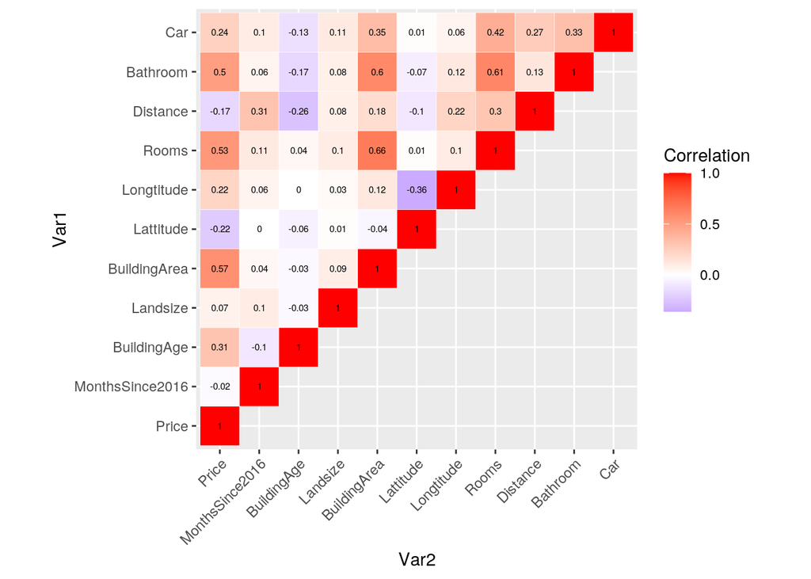

```r
get_lower_tri <- function(correlationmatrix_df) {
    correlationmatrix_df[upper.tri(correlationmatrix_df)] <- NA
    return(correlationmatrix_df)
}

lower_tri = get_lower_tri(correlationmatrix_df)

meltedcorrelationmatrix_df <- melt(lower_tri, na.rm = TRUE)
dfheatmap = ggplot(data = meltedcorrelationmatrix_df,
    aes(Var2, Var1, fill = value)) + geom_tile(color = "white") +
    scale_fill_gradient2(low = "blue", high = "red",
        mid = "white", space = "Lab", name = "Correlation") +
    theme(axis.text.x = element_text(angle = 45, vjust = 1,
        size = 9, hjust = 1)) + coord_fixed() + geom_text(aes(Var2,
    Var1, label = value), color = "black", size = 2)

dfheatmap
```

### Price by Map

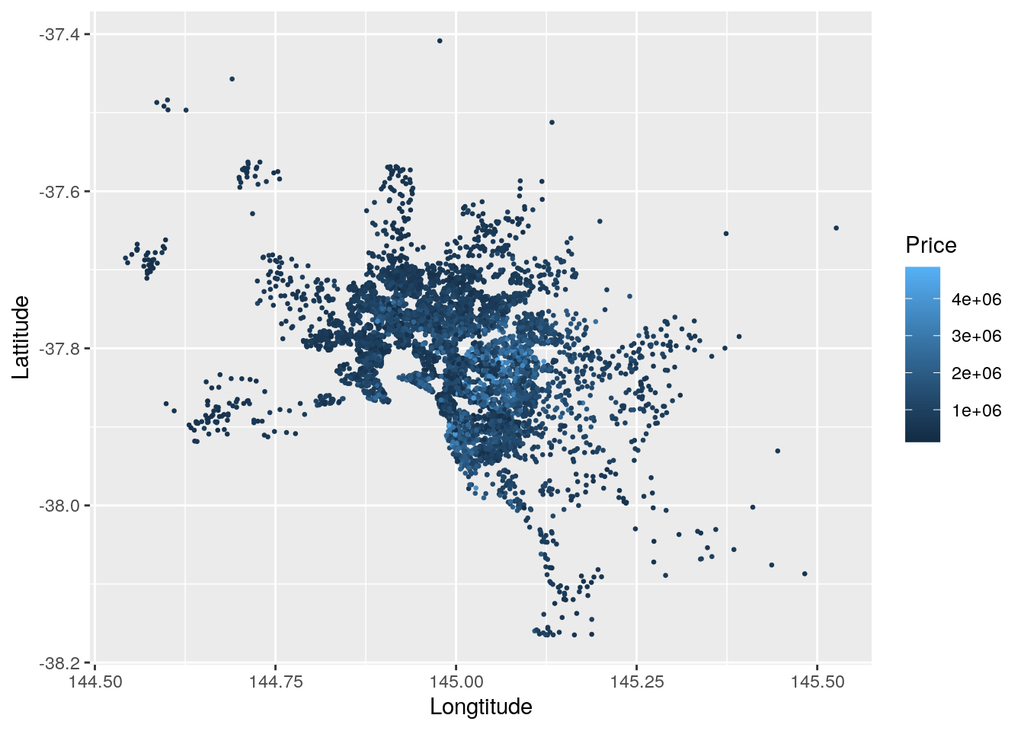

```r
ggplot(df, aes(x=Longtitude, y=Lattitude, col=Price)) + geom_point(size=0.5)
```

### Landsize

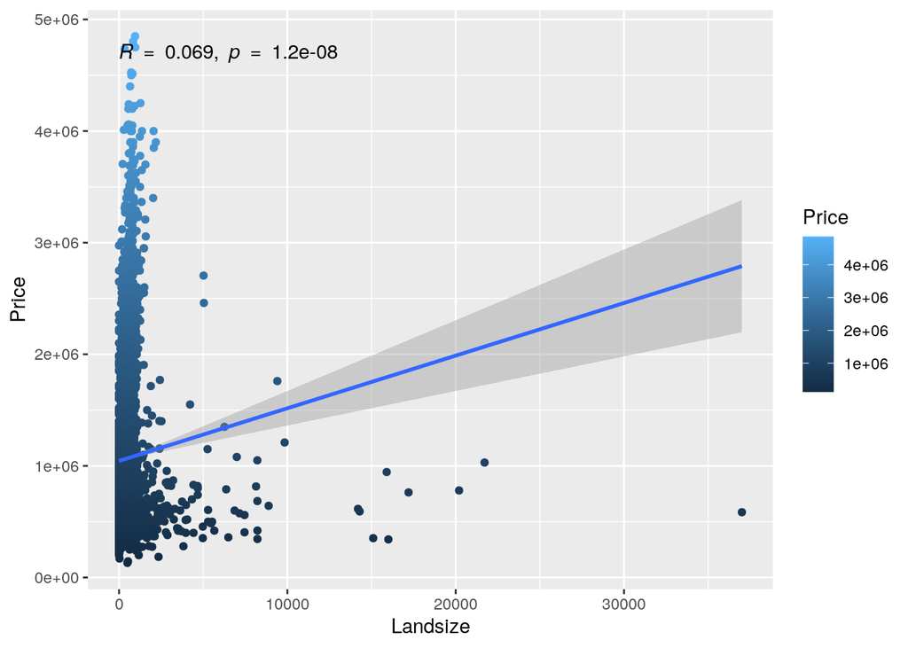

```r
p2 <- ggplot(df, aes(x=Landsize, y=Price))
p2 + geom_point(aes(color=Price)) + geom_smooth(method=lm) + stat_cor(method = "pearson")
```

### Building Area

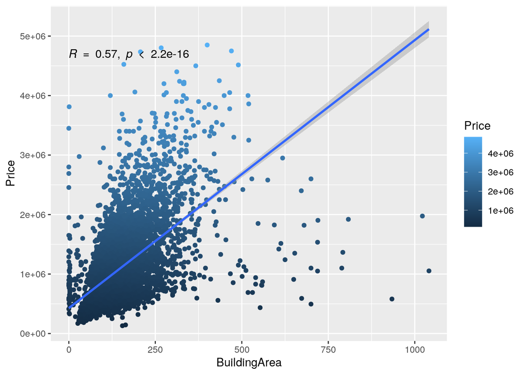

```r
p3 <- ggplot(df, aes(x=BuildingArea, y=Price))
p3 + geom_point(aes(color=Price)) + geom_smooth(method=lm) + stat_cor(method = "pearson")
```

### Distance

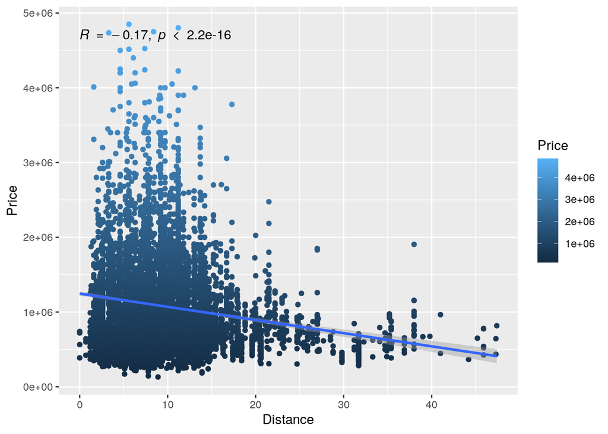

```r
p3 <- ggplot(df, aes(x=Distance, y=Price))
p3 + geom_point(aes(color=Price)) + geom_smooth(method=lm) + stat_cor(method = "pearson")
```

### BuildingArea by Regionname

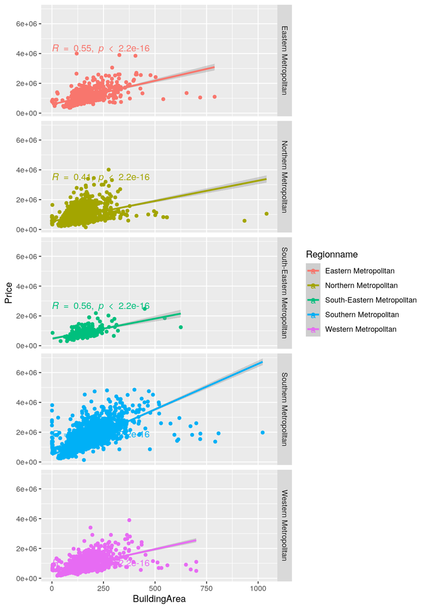

```r
p5 <- ggplot(df %>% filter(Regionname %in% c("Eastern Metropolitan", "Northern Metropolitan", "South-Eastern Metropolitan", "Southern Metropolitan", "Western Metropolitan")), aes(x=BuildingArea, y=Price, col=Regionname))
p5 + geom_point() + geom_smooth(method=lm) + stat_cor(method = "pearson") + facet_grid(rows=vars(Regionname))
```

### Distance by Regionname

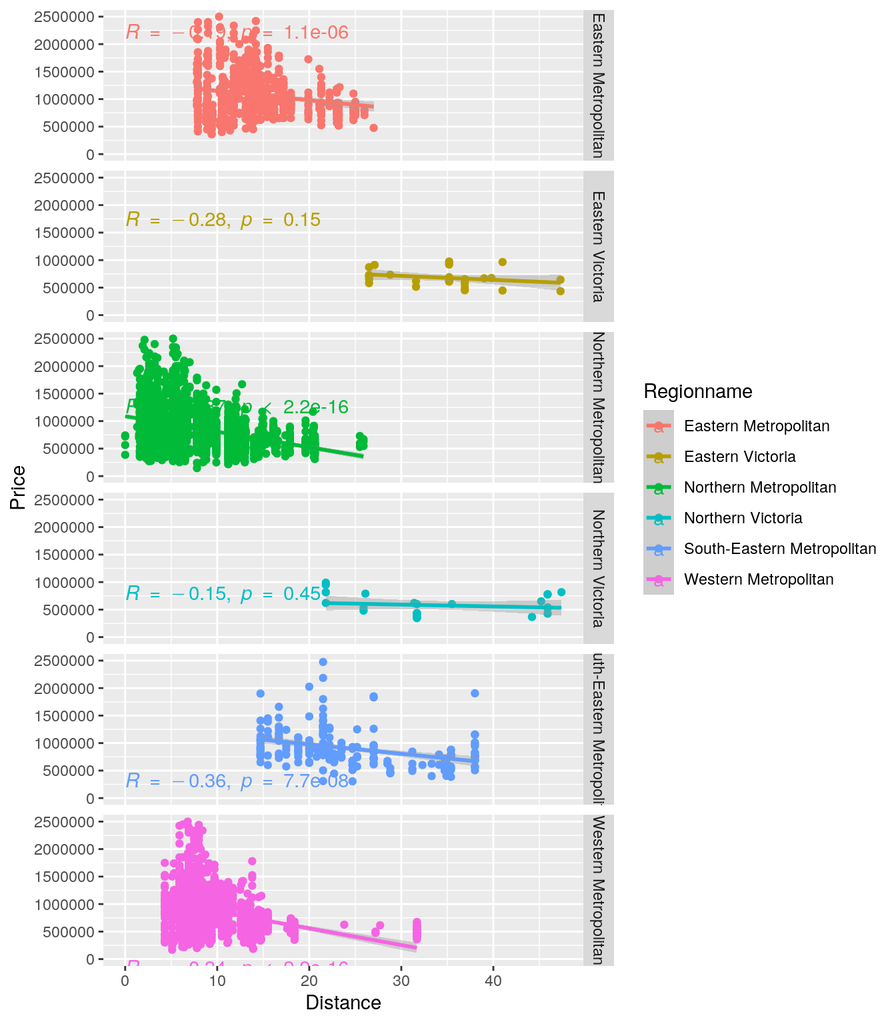

```r
df_Regionname <- df %>% filter(Regionname=="Eastern Metropolitan" | Regionname=="Northern Metropolitan" | Regionname=="South-Eastern Metropolitan" | Regionname=="Western Metropolitan" | Regionname=="Eastern Victoria" | Regionname=="Northern Victoria")
p6 <- ggplot(df_Regionname, aes(x=Distance, y=Price, color=Regionname))
p6 + geom_point() + geom_smooth(method=lm) + stat_cor(method = "pearson") + facet_grid(rows=vars(Regionname)) + scale_y_continuous(limits = c(0, 2500000))
```

# Hypothesis 1

The mean prices of properties are different based on number of rooms.

```r
summary(aov(Price ~ as.factor(Rooms), num_df))
```

```
##                    Df    Sum Sq   Mean Sq F value Pr(>F)
## as.factor(Rooms)    7 7.767e+14 1.110e+14   394.4 <2e-16 ***
## Residuals        6827 1.921e+15 2.813e+11
## ---
## Signif. codes:  0 '***' 0.001 '**' 0.01 '*' 0.05 '.' 0.1 ' ' 1
```

With a One-Factor ANOVA Test, since the p-value is less than 0.001, we have significant evidence that the group mean price of properties are not the same based on different number of rooms. Therefore, we will include room count in our model as it can significantly impact the property price prediction.

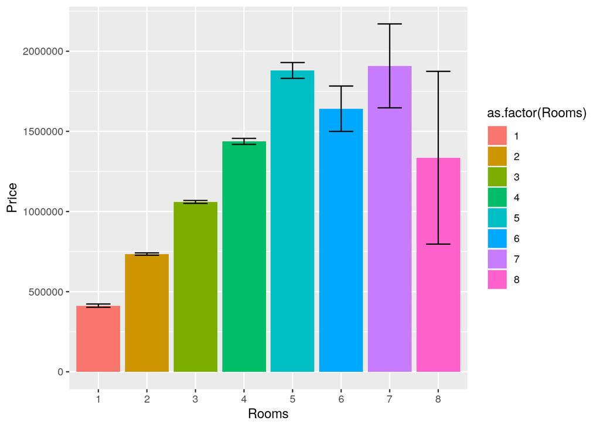

```r
ggplot(df, aes(x=as.factor(Rooms), y=Price, fill=as.factor(Rooms))) + xlab("Rooms") + ylab("Price") + geom_bar(aes(y=Price), stat="summary", fun=mean) + geom_errorbar(stat="summary", width=0.5)
```

# Hypothesis 2

```r
summary(aov(Price ~ Regionname, df))
```

```
##               Df    Sum Sq   Mean Sq F value Pr(>F)
## Regionname     7 3.859e+14 5.512e+13   162.8 <2e-16 ***
## Residuals   6827 2.311e+15 3.386e+11
## ---
## Signif. codes:  0 '***' 0.001 '**' 0.01 '*' 0.05 '.' 0.1 ' ' 1
```

With a One-Factor ANOVA Test, since the p-value is less than 0.001, we have significant evidence that the group mean price of properties are not the same based on different regions. Therefore, we will include region in our model as it can significantly impact the property price prediction.

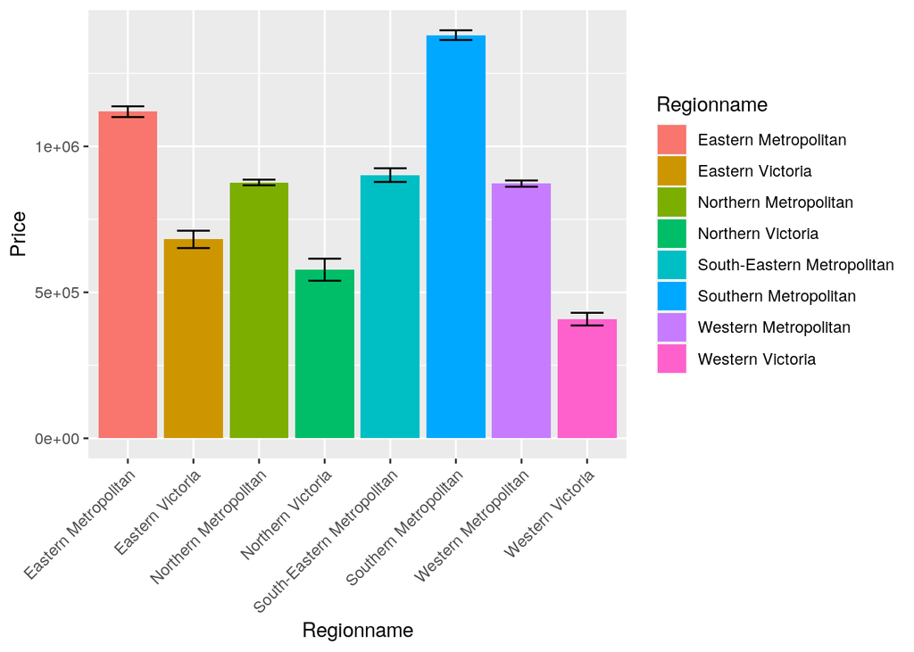

```r
ggplot(df, aes(x=Regionname, y=Price, fill=Regionname)) + xlab("Regionname") + ylab("Price") + geom_bar(aes(y=Price), stat="summary", fun=mean) + geom_errorbar(stat="summary", width=0.5) + theme(axis.text.x = element_text(angle = 45, vjust=1, hjust=1))
```

# Hypothesis 3

The Price data is normally distributed.

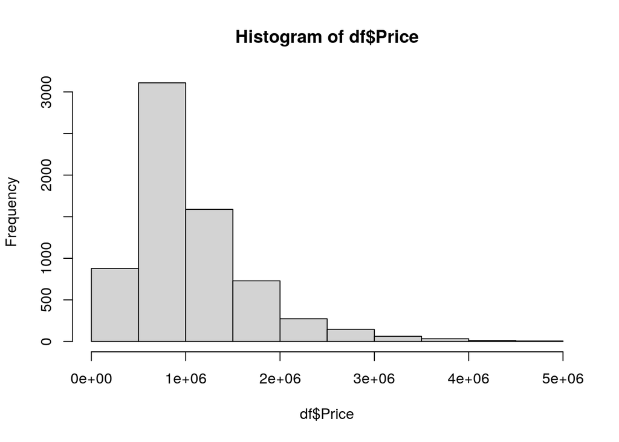

```r
hist(df$Price)
```

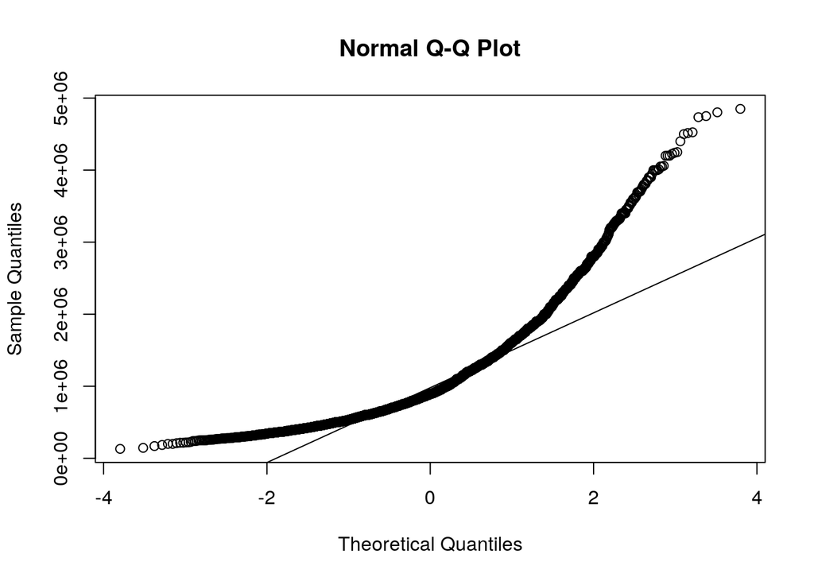

```r
qqnorm(df$Price); qqline(df$Price)
```

It’s not normally distributed. We have to log-transform it.

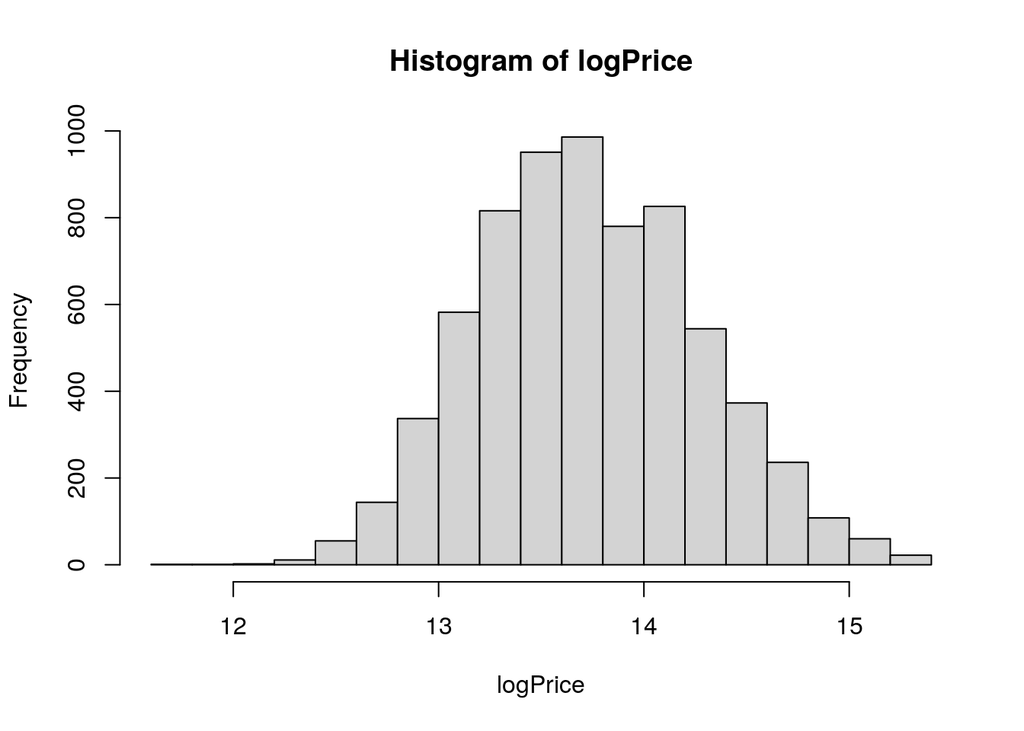

```r
logPrice <- log(df$Price)
hist(logPrice)
```

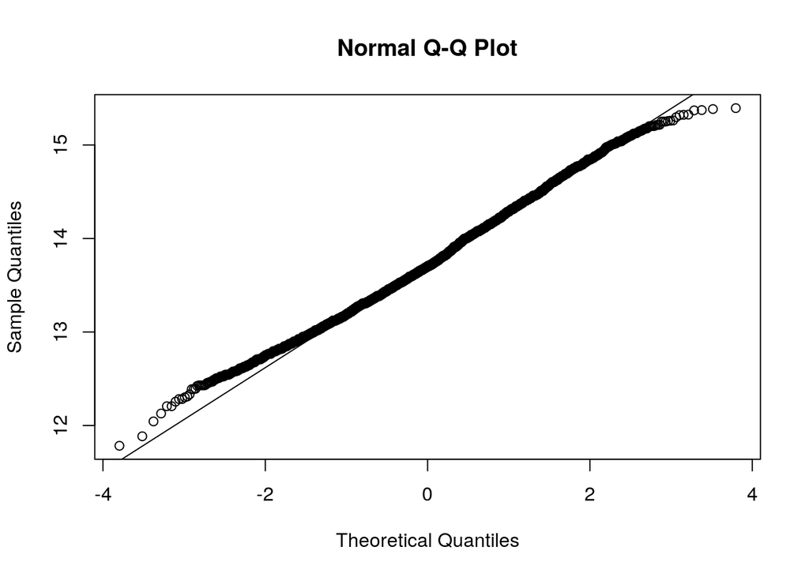

```r
qqnorm(logPrice); qqline(logPrice)
```

```r
df$logPrice <- logPrice
```

After applying log transformation to the Price data, we are ready to put it into our model for prediction.